# Problem Set 5, Solution to Question 1

Stats 506, F19

December 7, 2019

## About

This document was produced using `knitr::spin` which allows you to place markdown directly in an R script. When you write and compile Rmarkdown (.Rmd) the `knitr::knit` function does roughly the following:

1. executes your R code and interleaves it with the markdown in a .md file
2. calls pandocs to produce the outputs specified in the YAML header

The process is therefore: .Rmd $\to$ .md $\to$ (say) .html.

The knitr function `spin`` adds one level to this, allowing you to write your markdown specifications directly in a .R script: .R $\to$ .Rmd $\to$ .md $\to$ .html. I find this most useful for documents where the amount of text and markdown formatting is smaller or on par with the amount of actual R code.

From within Rstudio, you can compile the source (.R) script using `cmd + shift + k` or whatever your compile shortcut is.

In a spin document, markdown goes after a special comment `#'`. R code chunks and associated options follow `#+` (among other options).

The source code for this document can be found at the course [repo](https://github.com/jbhender/Stats506_F19/tree/master/problem_sets) as `ps5_q1_spin.R`. See also `ps5_q1.R` for the R script without markdown.

## Question

Our goal in this problem is to:

> Compare disparities in internet access betwen urban (including “urban cluster”) and rural areas.

## Header

```r
# Problem Set 5, Question 1
# Stats 506, Fall 2019
#
# This script estimates the disparity in internet acccess between urban and
# rural areas by census division, using the RECS 2015 data:
#
#  https://www.eia.gov/consumption/residential/data/2015/csv/
#    recs2015_public_v4.csv
#
# This repeats the analysis done in Problem Set 4, Question 2 using Stata.
#
# Author: James Henderson
# Date: December 7, 2019
# 80: --------------------------------------------------------------------------
```

## R packages

```r
# libraries: -------------------------------------------------------------------
suppressPackageStartupMessages({
  library(tidyverse); library(data.table)
})
```

## Data import

```r
# data: ------------------------------------------------------------------------
recs = fread('./recs2015_public_v4.csv')
```

## Point estimates

```r
# point estimates: -------------------------------------------------------------

## treat urban and urban cluster as the "urban"
recs[ , urban := ifelse(UATYP10 %in% c("U", "C"), 'urban', 'rural')]
# recs[,.N,.(UATYP10, urban)] ## check mapping

## proportion of homes with internet in each group
prop_internet_ur =
  recs[ , .(prop_internet = sum(INTERNET * NWEIGHT) / sum(NWEIGHT)),
        keyby = .(DIVISION, urban)]

## point estimate of disparity
disp_internet_ur =
  prop_internet_ur[ , .(delta_internet = diff(prop_internet)), DIVISION]
```

## Standard Errors

To compute the standard errors, we first pivot the weights to a long format.

```r
# pivot replicate weights to a long form for standard error computations: ------
recs_weights = melt(recs,
                    id.vars = 'DOEID',
                    measure.vars = grep('^BRR', names(recs), value = TRUE),
                    value.name = 'w',
                    variable.name = 'repl'
)
```

Next, we recompute the point estimates for each group for each set of replicate weights.

```r
# compute prop internet for each set of replicate weights: ---------------------
prop_internet_ur_repl =
  merge(recs_weights,
        recs[,.(DOEID, INTERNET, DIVISION, urban)],
        by = 'DOEID') %>%
  .[ , .(prop_internet_r = sum(INTERNET * w) / sum(w)),
     keyby = .(DIVISION, repl, urban)]

## replicate disparities
disp_internet_ur_repl =
  prop_internet_ur_repl[ , .(delta_internet_r = diff(prop_internet_r)),
                         .(DIVISION, repl)]
```

Now we can compute the standard errors by scaling the square root of the mean squared deviations between the replicate and point estimates.

```r
# compute standard errors using point and replicate estimates: -----------------
prop_internet_ur =
  merge( prop_internet_ur,
         prop_internet_ur_repl[, !"repl"],
         by = c('DIVISION', 'urban')
  ) %>%
  .[ , .( prop_internet = prop_internet[1],
          se = 2 * sqrt(mean({prop_internet_r - prop_internet}^2))
         ), .(DIVISION, urban) ]

disp_internet_ur =
  merge( disp_internet_ur,
         disp_internet_ur_repl[, !"repl"],
         by = c('DIVISION')
  ) %>%
  .[ , .( delta_internet = delta_internet[1],
          se = 2 * sqrt(mean({delta_internet_r - delta_internet}^2))
        ), .(DIVISION) ]
```

After computing the standard errors, we can form 95% confidence bounds. Here we do so using data.table reference semantics.

```r
# construct CI bounds and drop se using reference semantics: -------------------
m = qnorm(.975)

prop_internet_ur[ , `:=`(lwr = prop_internet - m * se,
                         upr = prop_internet + m * se,
                         se = NULL)]

disp_internet_ur[ , `:=`(lwr = delta_internet - m * se,
                         upr = delta_internet + m * se,
                         se = NULL)]
```

## Results

In this section we present our results. First, we order the divisions by the level of disparity in internet access and add the divison names. In the code below, we are implicitly ordering using `data.table::setkey()`. Like all `set()` functions in data.table, this orders by reference – the data is physically reordered in place.

```r
# make plots/tables more interpretable by ordering by disparity: ---------------

## order
divisions = c(
  "New England",
  "Middle Atlantic",
  "East North Central",
  "West North Central",
  "South Atlantic",
  "East South Central",
  "West South Central",
  "Mountain North",
  "Mountain South",
  "Pacific")
div_ord = disp_internet_ur[, order(delta_internet)]

## apply order
prop_internet_ur[ , division := factor(DIVISION, div_ord,
                                       labels = divisions[div_ord])]
setkey(prop_internet_ur, division)

disp_internet_ur[ , division := factor(DIVISION, div_ord,
                                       labels = divisions[div_ord])]
setkey(disp_internet_ur, division)
```

Next we format our results as a table. In this example, we use the html tags `<center>` and `<br>` (line break) to improve the appearance of the results.

```r
# Make a table with all three pieces of information: --------------------------
tab1 =
  prop_internet_ur[ , .(division, urban,
                      ci = sprintf('<center>%4.1f <br>(%4.1f, %4.1f)</center>',
                                   100 * prop_internet, 100 * lwr, 100 * upr) )
 ] %>%
 dcast(., division ~ urban, value.var = 'ci' )

tab1 =
  disp_internet_ur[ ,
   .(division, disparity = sprintf('<center>%4.1f <br>(%4.1f, %4.1f)</center>',
                             100 * delta_internet, 100 * lwr, 100 * upr) )
   ] %>%
   merge( tab1, ., by = 'division')

tab1 = tab1[order(-division)]
setnames(tab1, c('Census Division',
                 'Rural, % <br> (95% CI)',
                 'Urban, % <br> (95% CI)',
                 'Disparity, % <br> (95% CI)'
                 )
         )
DT::datatable(tab1, escape = FALSE)
```

|  | Census Division | Rural, % (95% CI) | Urban, % (95% CI) | Disparity, % (95% CI) |
| --- | --- | --- | --- | --- |
| 1 | Mountain South | 66.7 (58.3, 75.2) | 85.3 (81.3, 89.2) | 18.5 ( 7.2, 29.8) |
| 2 | East South Central | 69.0 (63.5, 74.6) | 78.4 (70.5, 86.2) | 9.3 (-1.4, 20.1) |
| 3 | West North Central | 80.3 (71.5, 89.2) | 88.0 (84.6, 91.4) | 7.7 (-2.5, 17.8) |
| 4 | Mountain North | 81.9 (73.8, 90.0) | 87.4 (82.0, 92.9) | 5.5 (-6.2, 17.2) |
| 5 | West South Central | 76.5 (72.1, 80.9) | 81.6 (76.4, 86.8) | 5.1 (-2.3, 12.5) |
| 6 | Pacific | 85.3 (77.4, 93.1) | 88.7 (86.2, 91.2) | 3.4 (-4.5, 11.4) |
| 7 | South Atlantic | 82.0 (76.3, 87.8) | 85.3 (82.6, 88.0) | 3.3 (-3.5, 10.1) |
| 8 | New England | 85.8 (82.4, 89.2) | 87.6 (82.5, 92.6) | 1.8 (-2.5, 6.0) |
| 9 | East North Central | 86.2 (81.6, 90.8) | 86.3 (83.8, 88.7) | 0.0 (-5.3, 5.4) |
| 10 | Middle Atlantic | 91.3 (85.3, 97.3) | 89.3 (83.9, 94.8) | -1.9 (-9.1, 5.2) |

Finally, we plot the estiamtes proportions and disparities.

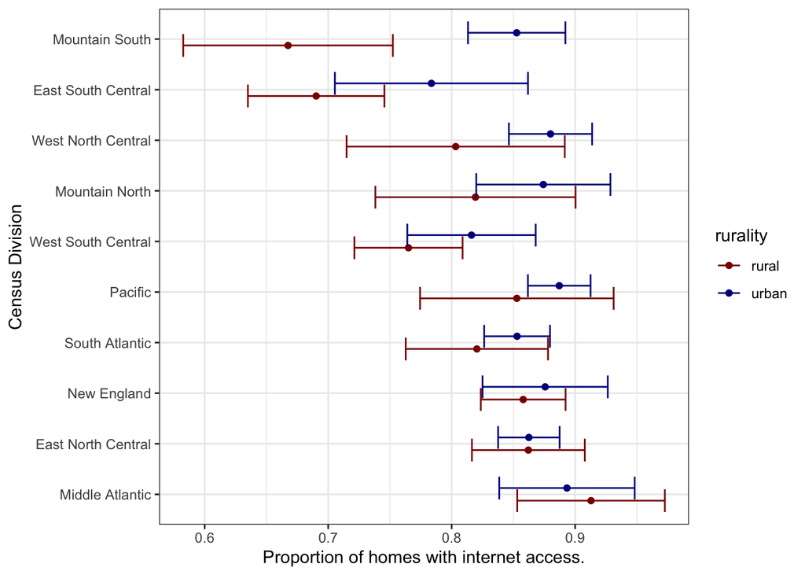

**Figure 1.** *Estimated proportion of homes with internet access by rurality in each Census Division.*

```r
# plots urban / rural internet proportions: ------------------------------------
p1 =
  prop_internet_ur %>%
  rename( rurality = urban ) %>%
  ggplot( aes( x = division, color = rurality) ) +
  geom_point( aes(y = prop_internet), position = position_dodge(width = 0.5) ) +
  geom_errorbar( aes(ymin = lwr, ymax = upr),
                 position = position_dodge(width = 0.5) ) +
  theme_bw() +
  scale_color_manual( values = c("darkred", "darkblue")) +
  ylab("Proportion of homes with internet access.") +
  xlab("Census Division") +
  coord_flip()
cap1 = paste(
  '**Figure 1.** *Estimated proportion of homes with internet access by',
  'rurality in each Census Division.*')
p1
```

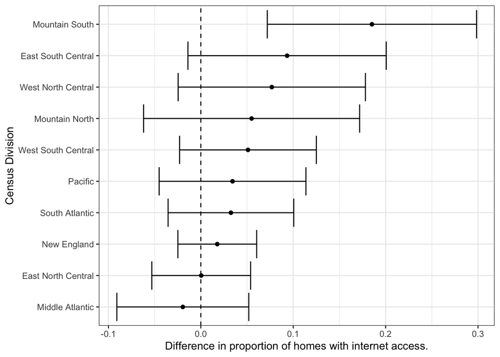

**Figure 2.** *Estimated disparity in internet access (urban less rural) by Census Division.*

```r
# plot the disparity: ----------------------------------------------------------
p2 =
  disp_internet_ur %>%
  ggplot( aes( x = division)  ) +
  geom_point( aes(y = delta_internet) ) +
  geom_errorbar( aes(ymin = lwr, ymax = upr) ) +
  theme_bw() +
  scale_color_manual( values = c("darkred", "darkblue")) +
  ylab("Difference in proportion of homes with internet access.") +
  xlab("Census Division") +
  geom_hline(yintercept = 0, lty = 'dashed') +
  coord_flip()
cap2 = paste(
  '**Figure 2.** *Estimated disparity in internet access (urban less rural) by',
  'Census Division.*'
)
p2
```